# Analisi Top 5000 album nella storia

2023-05-30

## Intro

Analizziamo la classifica mondiale dei top 5000 album musicali. Utilizziamo un dataset trovato su [kaggle](https://www.kaggle.com/datasets/lucascantu/top-5000-albums-of-all-time-spotify-features), basato sulle classifiche di Spotify.

## Spotify

Spotify è un noto servizio musicale di streaming svedese, si tratta di uno dei servizi di streaming più utilizzati dal pubblico, grazie alla sua semplicità di utilizzo e ai suoi algoritmi che permettono all’utente di scoprire nuova musica basandosi sugli ascolti precedenti, attraverso la creazione di playlist mix costruite appositamente per il consumatore.

[figure not shown]

Ad Aprile 2023 conta oltre 515 milioni di utenti, di cui oltre 200 milioni usano la versione premium.

## Cosa andremo ad analizzare?

Gli obiettivi dello studio sono principalmente:

- Vedere quali sono gli artisti che appaiono più volte nella classifica
- Vedere quali sono le fasce di anni in cui sono presenti più album in classifica
- Confrontare i generi degli album
- Analizzare la musica dell’artista più presente: generi che suona e altre caratteristiche

## Quali sono gli artisti più presenti nella Top?

Di seguito troviamo un grafico rappresentante i 10 artisti<sup>1</sup> presenti più volte nella classifica .

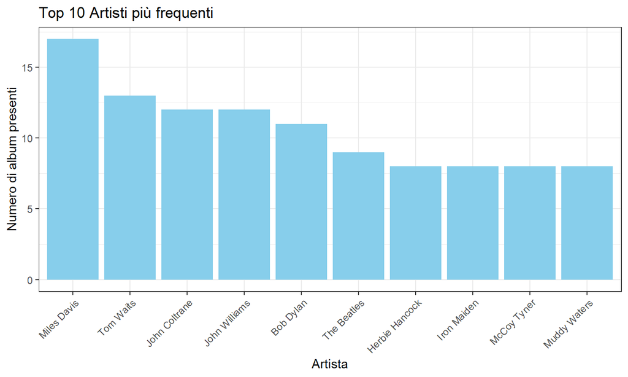

1: Escludiamo la voce **Various Artists**

## Anno più produttivo

Analisi temporale della produttività musicale.

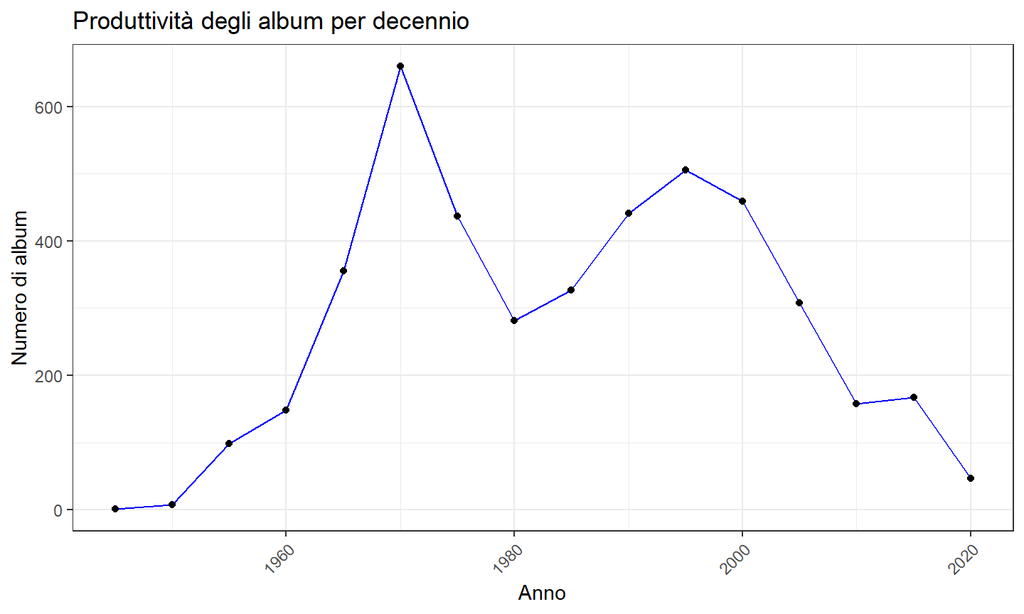

## Grafico dei generi

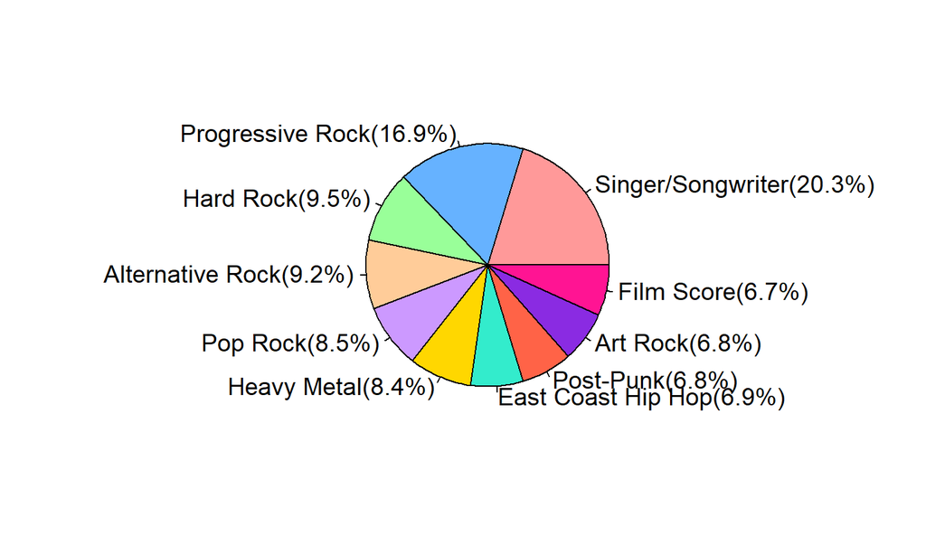

## Durata media delle canzoni negli anni

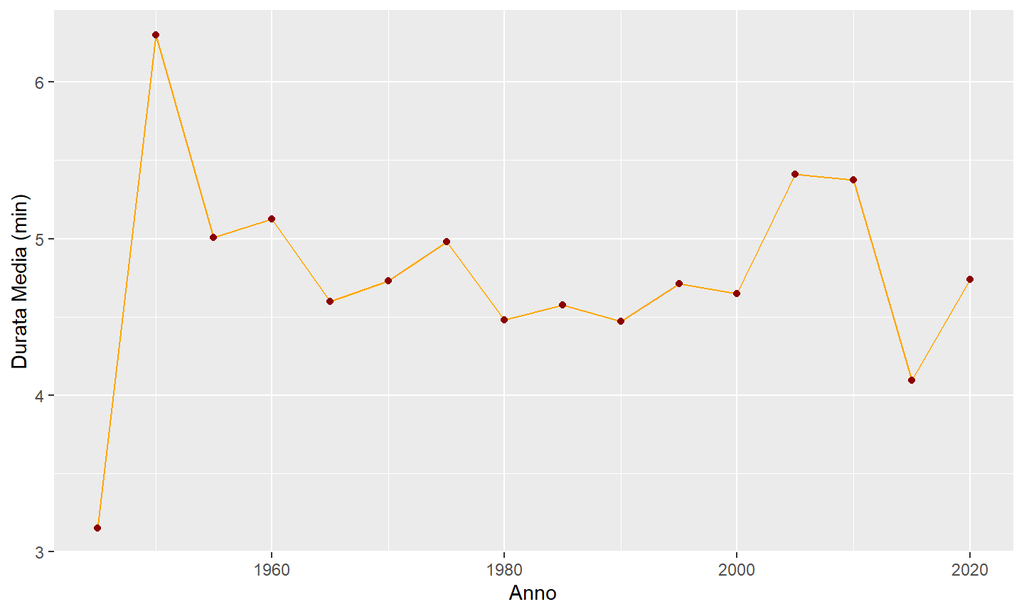

## Keyword maggiormente presenti nelle descrizioni

[interactive chart not shown]

## Apprezzamento del pubblico

Andiamo a vedere come è variato il rating degli album nel tempo.

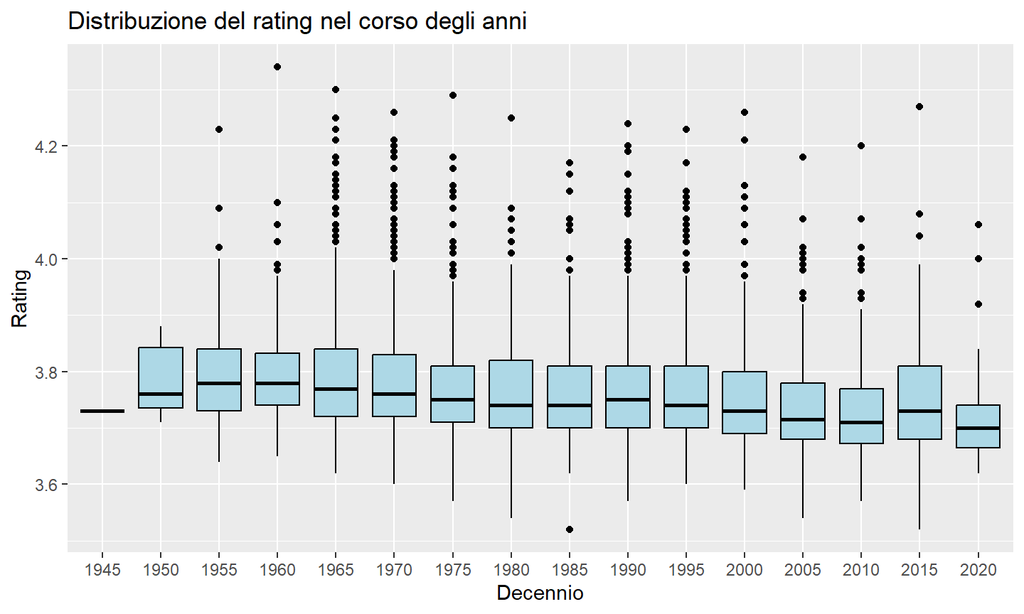

## Miles Davis

## Miles Davis viaggia nei sottogeneri del jazz

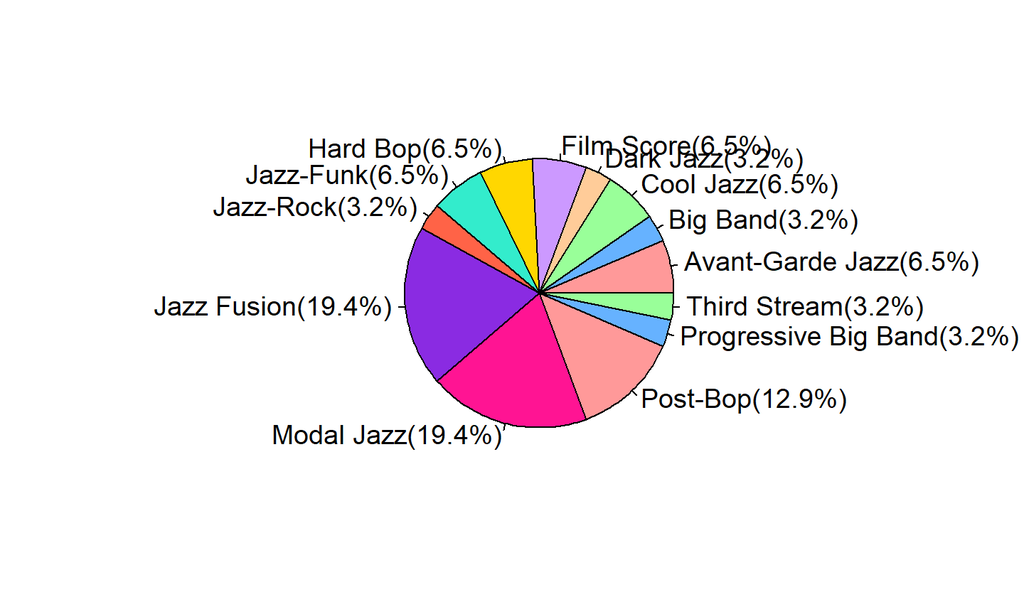

## Miles Davis: Ballabilità

Con ballabilità si intende la predispozione delle canzoni ad essere usate in sale da ballo o discoteche.

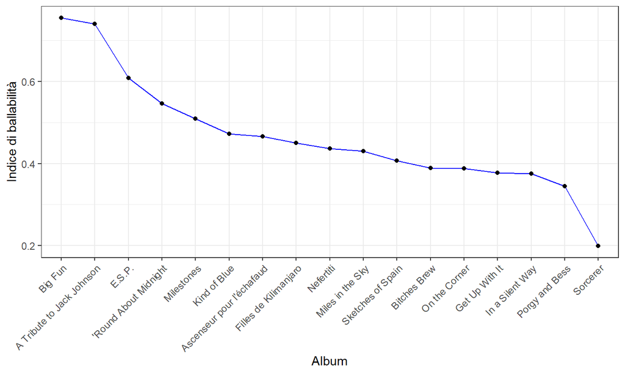

## Miles Davis: Live performance

Si possono eseguire dal vivo?

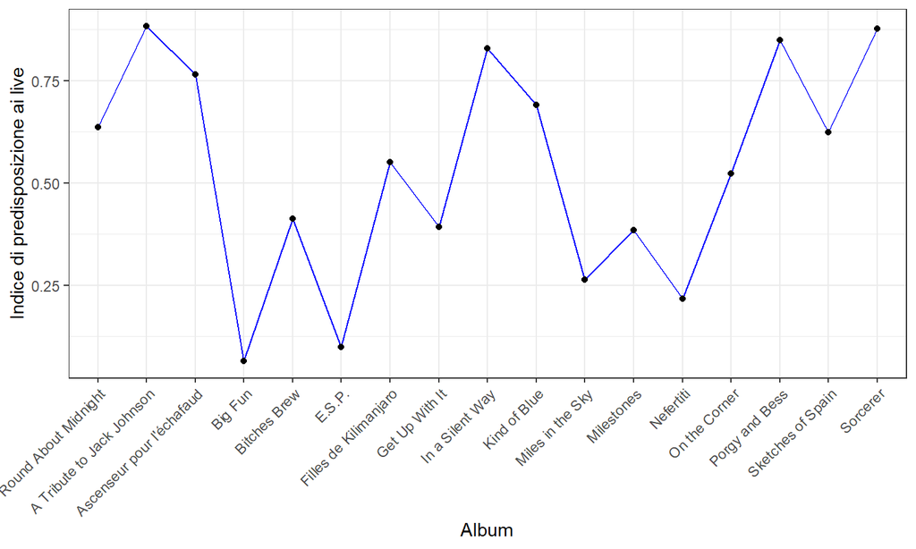

## Miles Davis: Energia

Quanta energia trasmettono?

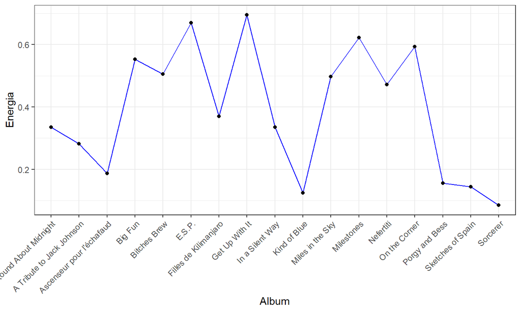